# Module09 Notes

Dani Antos

September 28, 2017

We’re talking about statistical inference and hypothesis testing

**critical value** corresponds to the quantile limits of interest; +/- 1-(alpha/2) -has to be derived from the sampling that we’re talking about

```r
library(curl)
n <- 1000
mu <- 3.5
sigma <- 4
v <- rnorm(n, mu, sigma)
s <- sample(v, size = 30, replace = FALSE)
s
```

```
##  [1]  1.9110231  3.3337644  7.1314867  2.5233658  8.9951457 -0.6486842
##  [7]  2.2649716  0.6180358  7.7492584 -1.4256804  4.0542698  2.8539307
## [13]  0.2164531  7.9267098  4.7140209 -0.9181653 -0.7279451  2.8770017
## [19]  8.1408578  3.7348819  3.1603996  8.3377970 -0.8322833  0.8983736
## [25]  2.2971072 11.1356163  2.4927200  5.9449551  2.1338853  9.2731491
```

```r
m <- mean(s)
m
```

```
## [1] 3.672214
```

```r
sd <- sd(s)
sd
```

```
## [1] 3.515035
```

```r
sem <- sd(s)/sqrt(length(s))
sem
```

```
## [1] 0.6417547
```

```r
lower <- m- qnorm(1-0.05/2)*sem
upper <- m+ qnorm(1-0.05/2)*sem
ci<- c(lower, upper)
ci
```

```
## [1] 2.414398 4.930030
```

**Central Limit Theorem**= distribution of averages and independent & identically distributed (iid) random variables becomes normal as the sample size increases. Allows us to have a good sense of the mean and distribution of average events in a population, and to make inferences about a population based on a sample.

Example- we’re taking averages of samples from a non-normal distribution. Using Poisson distribution where lambda=14, so mu and sigma^2 are equal to lambda. Using sample size n=10

```r
lambda <- 14
n <- 10
pop_se <- sqrt(lambda/n)
pop_se
```

```
## [1] 1.183216
```

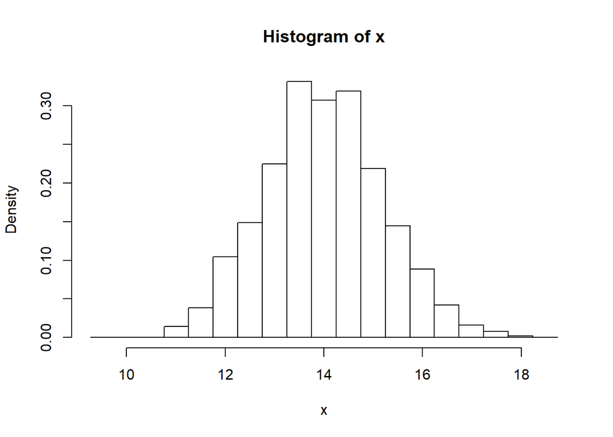

```r
x <- NULL
for (i in 1:1000) {
    x[i] <- mean(rpois(n = n, lambda = lambda))
}
hist(x, breaks = seq(from = lambda - 4 * sqrt(lambda)/sqrt(n), to = lambda +
    4 * sqrt(lambda)/sqrt(n), length.out = 20), probability = TRUE)
```

```r
sd <- sd(x)
sd
```

```
## [1] 1.207899
```

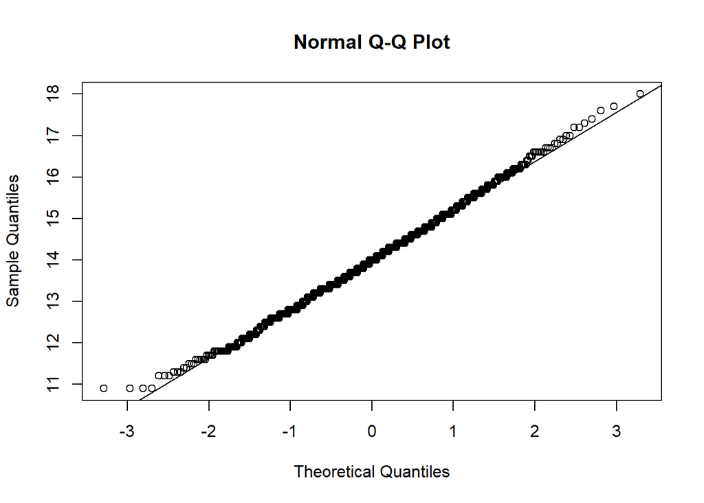

```r
qqnorm(x)
qqline(x)
```

Repeating the example, except n=100, not 10.

```r
n <- 100
pop_se <- sqrt(lambda/n)
pop_se
```

```
## [1] 0.3741657
```

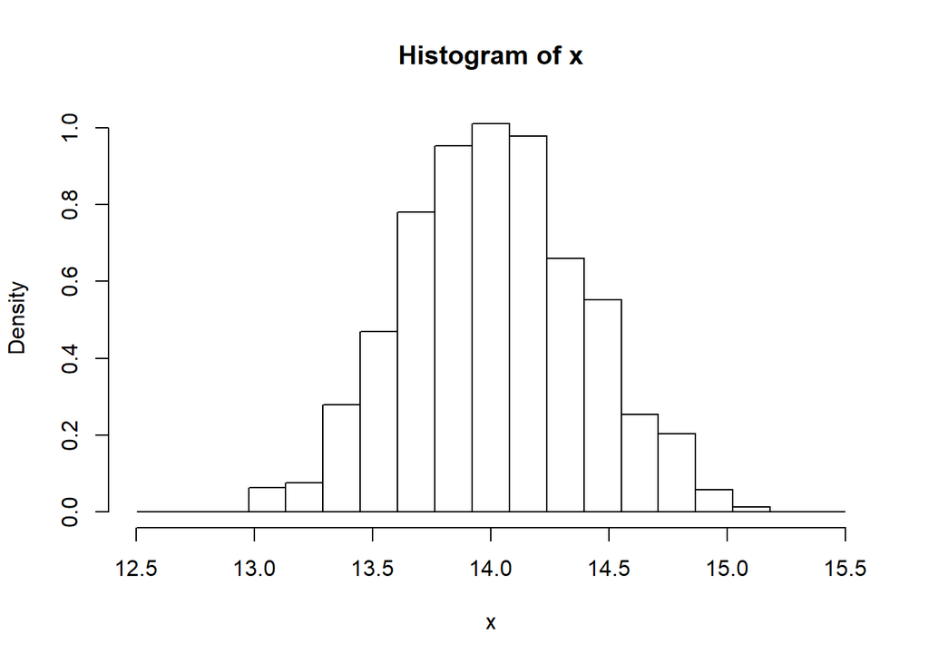

```r
x <- NULL
for (i in 1:1000) {
    x[i] <- mean(rpois(n = n, lambda = lambda))
}
hist(x, breaks = seq(from = lambda - 4 * sqrt(lambda)/sqrt(n), to = lambda +
    4 * sqrt(lambda)/sqrt(n), length.out = 20), probability = TRUE)
```

```r
sd <- sd(x)
sd
```

```
## [1] 0.3784119
```

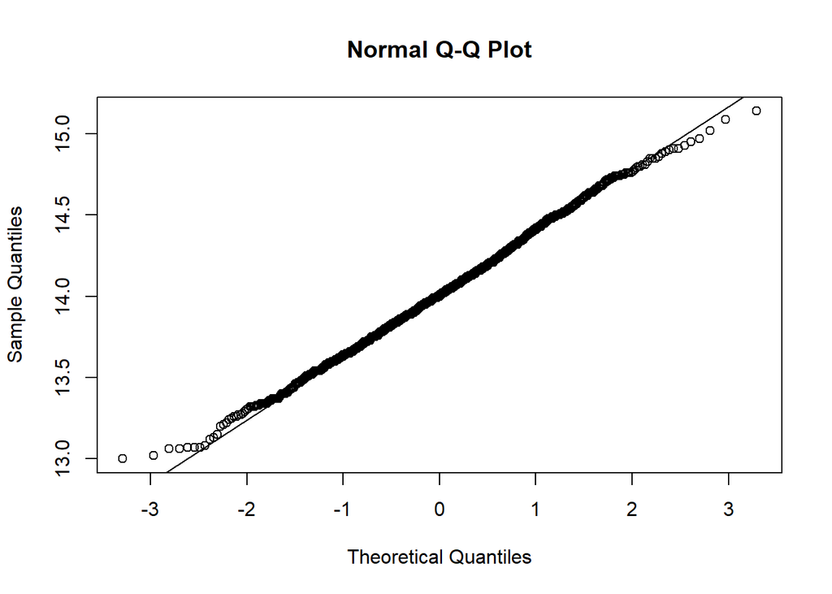

```r
qqnorm(x)
qqline(x)
```

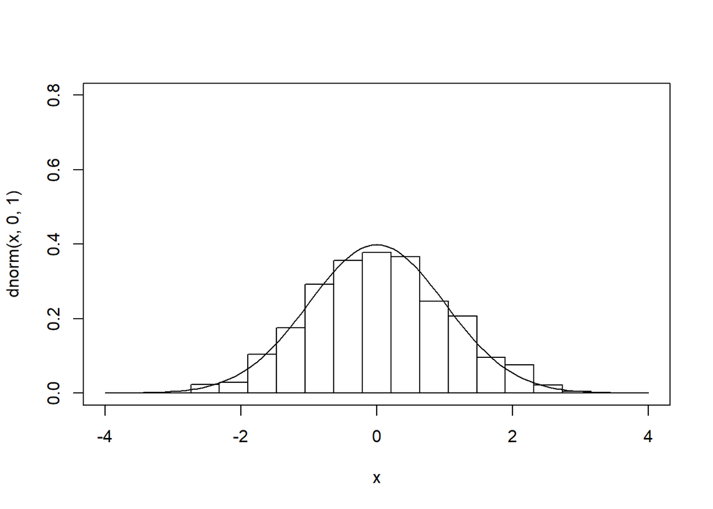

```r
curve(dnorm(x, 0, 1), -4, 4, ylim = c(0, 0.8))
z <- (x - lambda)/pop_se
hist(z, breaks = seq(from = -4, to = 4, length.out = 20), probability = TRUE,
    add = TRUE)
```

CLT example using sum instead of mean

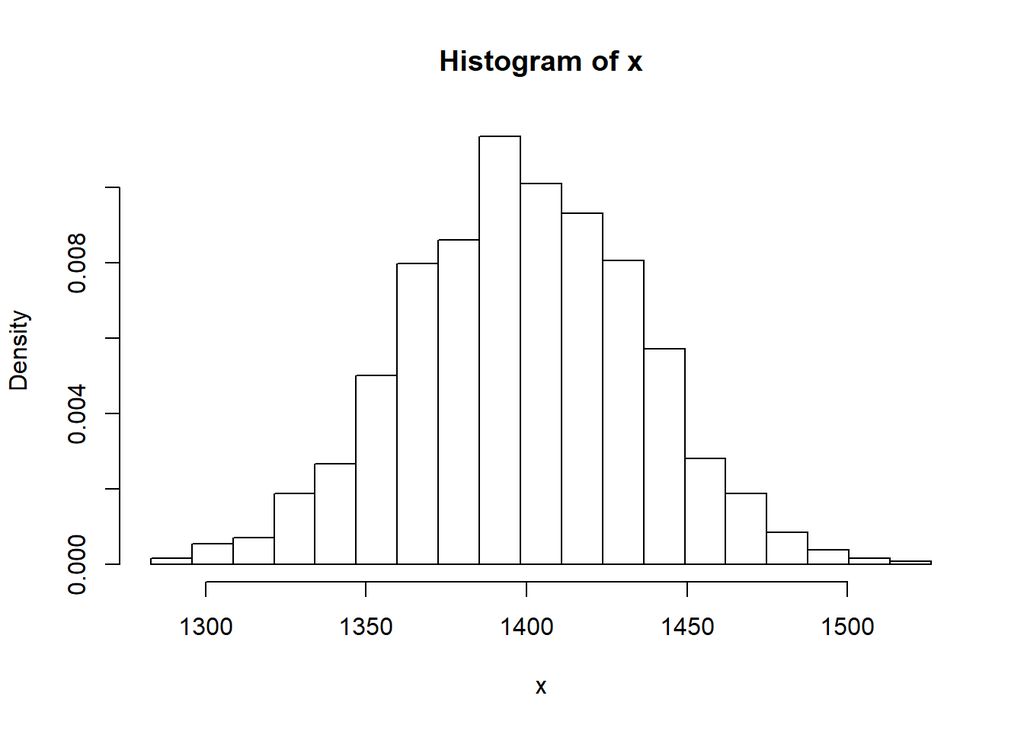

```r
n <- 100
x <- NULL
for (i in 1:1000) {
    x[i] <- sum(rpois(n = n, lambda = lambda))
}
hist(x, breaks = seq(min(x), max(x), length.out = 20), probability = TRUE)
```

Take home points: -regardless of distribution, a sampling of averages, sums, etc. will be approximately normal and centered at the mean -standard deviation of these averages will be approximately equal to standard error of the mean

So basically, a distribution of averages will be approximately normal, will be centered at the population mean, and the sd will be roughly equal to the se of the mean. As sample size increases, the standard error of the mean decreases and the distribution becomes more normal.

We can construct confidence intervals for statistics OTHER THAN the mean

```r
n <- 1000
x <- 856
phat <- x/n
phat
```

```
## [1] 0.856
```

```r
n * phat
```

```
## [1] 856
```

```r
n * (1-phat)
```

```
## [1] 144
```

```r
pop_se <- sqrt((phat) * (1 - phat)/n)
pop_se
```

```
## [1] 0.01110243
```

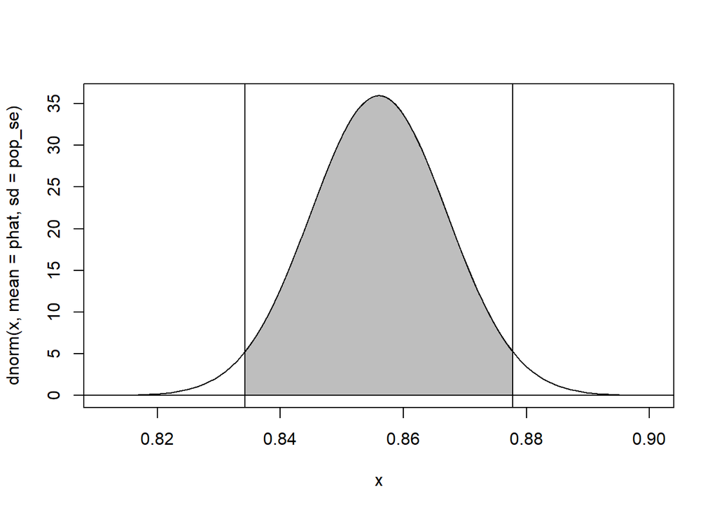

```r
#setting up 95% CI
curve(dnorm(x, mean = phat, sd = pop_se), phat - 4 * pop_se, phat + 4 * pop_se)
upper <- phat + qnorm(0.975) * pop_se
lower <- phat - qnorm(0.975) * pop_se
ci <- c(lower, upper)
polygon(cbind(c(ci[1], seq(from = ci[1], to = ci[2], length.out = 1000), ci[2]),
    c(0, dnorm(seq(from = ci[1], to = ci[2], length.out = 1000), mean = phat,
        sd = pop_se), 0)), border = "black", col = "gray")
abline(v = ci)
abline(h = 0)
```

# Small Sample Confidence Intervals

if n<30, then we use the t distribution. It’s similar in shape to the normal distribution: bell shaped, symmetric, and unimodal. This is typically what we will use

**degrees of freedom** are important when dealing with a t distribution…at a low df, the tails of the distribution get really fat -defined as the number of components that are free to change within a given statistic -basic change is that “z quantile” is replaced with a “t quantile” dependent on sample size

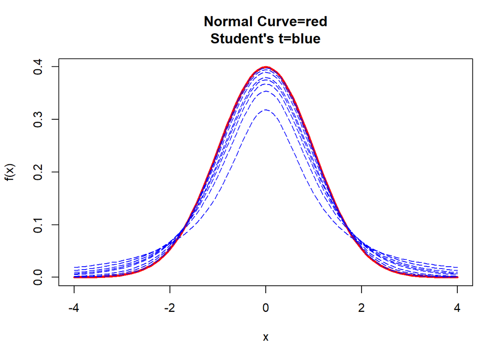

```r
mu <- 0
sigma <- 1
curve(dnorm(x, mu, 1), mu - 4 * sigma, mu + 4 * sigma, main = "Normal Curve=red\nStudent's t=blue",
    xlab = "x", ylab = "f(x)", col = "red", lwd = 3)
for (i in c(1, 2, 3, 4, 5, 10, 20, 100)) {
    curve(dt(x, df = i), mu - 4 * sigma, mu + 4 * sigma, main = "T Curve", xlab = "x",
        ylab = "f(x)", add = TRUE, col = "blue", lty = 5)
}
```

```r
n <- 1e+05
mu <- 3.5
sigma <- 4
x <- rnorm(n, mu, sigma)
sample_size <- 30
s <- sample(x, size = sample_size, replace = FALSE)
m <- mean(s)
m
```

```
## [1] 3.655356
```

```r
sd <- sd(s)
sd
```

```
## [1] 4.350355
```

```r
sem <- sd(s)/sqrt(length(s))
sem
```

```
## [1] 0.7942625
```

```r
lower <- m - qnorm(1 - 0.05/2) * sem
upper <- m + qnorm(1 - 0.05/2) * sem
ci_norm <- c(lower, upper)
ci_norm
```

```
## [1] 2.098630 5.212081
```

```r
#ci for a t distribution
lower <- m - qt(1 - 0.05/2, df = sample_size - 1) * sem
upper <- m + qt(1 - 0.05/2, df = sample_size - 1) * sem
ci_t <- c(lower, upper)
ci_t
```

```
## [1] 2.030906 5.279805
```

```r
#what if the sample size is much smaller than 30, ie 5?
sample_size <- 5
s <- sample(x, size = sample_size, replace = FALSE)
m <- mean(s)
m
```

```
## [1] 3.828871
```

```r
sd <- sd(s)
sd
```

```
## [1] 1.740642
```

```r
sem <- sd(s)/sqrt(length(s))
sem
```

```
## [1] 0.7784388
```

```r
lower <- m - qnorm(1 - 0.05/2) * sem
ci_norm <- c(lower, upper)
ci_norm
```

```
## [1] 2.303159 5.279805
```

```r
lower <- m - qt(1 - 0.05/2, df = sample_size - 1) * sem
upper <- m + qt(1 - 0.05/2, df = sample_size - 1) * sem
ci_t <- c(lower, upper)
ci_t
```

```
## [1] 1.667579 5.990164
```